title: “Chen lab RNA-seq” output: html_notebook #human cell lines # si RNA knockdown experiment

```r
library(pheatmap)
library(edgeR)
library(DESeq2)
library(biomaRt)
library(ggplot2)
```

Read in files

```r
filename = "~/Documents/chen/readcounts.txt"
counts1 = read.table(filename, header = T, stringsAsFactors = F)
rownames(counts1) = counts1$Geneid
```

Remove metadata (Gene, coordinates, etc)

```r
counts2 = counts1[,7:ncol(counts1)]
colnames(counts2) = sub("_1_algn_Aligned", "", matrix(unlist(strsplit(colnames(counts2), "\\.")), byrow =T, ncol=6)[,3])
```

Filter out genes with low and high counts ( high counts might be mitochondrial genes)

```r
keep = rowMeans(counts2) > 5 & rowMeans(counts2) < 5000
counts3 = counts2[keep,]
```

```r
#counts4 = counts3 + 1
counts4 = counts3
```

Take the log (RPKM)

```r
y <- DGEList(counts=counts4)
fpkm_log_matrix = rpkm (y, gene.length=counts1[keep,"Length"], log = TRUE)
```

Dendrogram

[figure not shown]

```r
#
#par(cex=1,font=3)
hc2 <- hclust(stats::dist(t(fpkm_log_matrix), method="minkowski"), "ward.D2")
#par(mar=c(10, 4, 4, 10), pty='s')
plot(hc2, lwd=4, lty=1, col="black", col.lab="red", xlab="Samples", main="Samples clustered by log2(FPKM+1) using Ward's clustering & Euclidean distance")
```

Some replicates don’t cluster (see FocusT replicates). Samples cluster by cell type. SS49 and SS475 are more similar than the other cell types.

Setup up design matrix for PCA plot

```r
groupNamesPerSample = matrix (unlist(strsplit(colnames(counts4), "_")), byrow=T, ncol=4) [,1]
groupNamesPerSample = unlist( lapply (groupNamesPerSample, function(x) sub("S475", "", sub("S449", "", sub("PLC", "", sub("Focus", "", x))))) )
conditionFactor  <- factor(groupNamesPerSample)
subjectgroup = matrix (unlist(strsplit(colnames(counts4), "_")), byrow=T, ncol=4) [,1]
subjectgroup = unlist( lapply (subjectgroup, function(x) sub("SC", "", sub("YT", "", sub("T", "", sub("Y", "", x))))) )
Subject <- factor(subjectgroup)
```

PCA plot

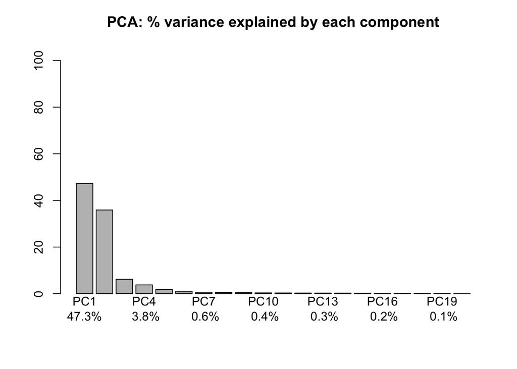

```r
cold <- data.frame("conditionFactor"=conditionFactor, "Subject"=Subject) #"sample_name"=colnames(counts4)
design_matrix <- model.matrix( ~Subject + conditionFactor)
ddsMat <- DESeq2::DESeqDataSetFromMatrix(countData=counts4, colData=cold, design=~conditionFactor);
colnames(ddsMat) <- colnames(counts4)
rld <- DESeq2::rlog(ddsMat) # LOG TRANSFORMED.
#rld <- DESeq2::rlog(ddsMat, blind=blind_status)

pca              <- prcomp(t(assay(rld)))
allPer.vec       <- 100 * summary(pca)$importance[2,]
allPer.text      <- paste(format(allPer.vec,digits=0, nsmall=1, scientific=FALSE), "%", sep='')
allPerLabels.vec <- paste(names(allPer.vec), "\n", allPer.text, sep='')

barplot(allPer.vec, main="PCA: % variance explained by each component\n" , ylim=c(0,100), names.arg=allPerLabels.vec)
```

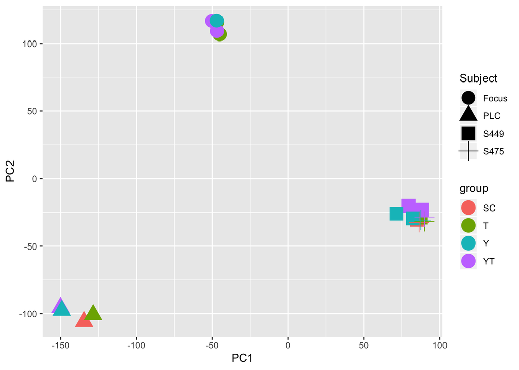

```r
d <- data.frame(pca$x, group=conditionFactor, Subject, name=colnames(rld)) # returns PC1, PC2, ... PC8... etc
ppp <- ggplot(d, aes_string(x="PC1", y="PC2", shape="Subject", color="group"))
ppp <- ppp + geom_point(size=6)
plot(ppp)
```

Samples seem to cluster by cell type. S449 and S475 appear to be very similar. Replicates cluster together mostly.

Concatenate samples with replicates

```r
#done manually using counts3 because I don't want to use matrix counts with 1 added to the value
counts5 = data.frame(
            counts3$FocusSC_USR17001380L_HJHCJBBXX_L6
          , counts3$FocusT_USR17001382L_HJHCJBBXX_L7 + counts3$FocusT_USR17001382L_HKF5JBBXX_L1
          , counts3$FocusYT_USR17001383L_hkff7BBXX_L1 + counts3$FocusYT_USR17001383L_HKY5KBBXX_L1
          , counts3$FocusY_USR17001381L_HJHCJBBXX_L6

          , counts3$PLCSC_USR17002043L_HJHCJBBXX_L7
          , counts3$PLCT_USR17002044L_HJHCJBBXX_L7
          , counts3$PLCYT_USR17001379L_HJHCJBBXX_L6
          , counts3$PLCY_USR17001377L_HJHCJBBXX_L6

          , counts3$S449SC_USR17001384L_HJHCJBBXX_L7
          , counts3$S449T_USR17001386L_HJHCJBBXX_L7
          , counts3$S449YT_USR17002046L_HJHCJBBXX_L7 + counts3$S449YT_USR17002046L_HKF5JBBXX_L3
          , counts3$S449Y_USR17001385L_HJHCJBBXX_L7 + counts3$S449Y_USR17001385L_HKF5JBBXX_L3

          , counts3$S475SC_USR17001372L_HJHCJBBXX_L6
          , counts3$S475T_USR17001374L_HJHCJBBXX_L6
          , counts3$S475YT_USR17001375L_HJHCJBBXX_L6
          , counts3$S475Y_USR17001373L_HJHCJBBXX_L6
          )

colnames(counts5) = unlist(lapply (strsplit(sub("counts3.", "" ,colnames(counts5)) , "_"), `[[`, 1))
rownames(counts5) = rownames(counts3)
```

Setup up design matrix for DE

```r
Condition = unlist( lapply (colnames(counts5), function(x) sub("S475", "", sub("S449", "", sub("PLC", "", sub("Focus", "", x))))) )
Condition  <- factor(Condition)
Subject2 = unlist( lapply (colnames(counts5), function(x) sub("SC", "", sub("YT", "", sub("T", "", sub("Y", "", x))))) )
Subject2 <- factor(Subject2)
cold <- data.frame("Condition"=Condition, "Subject2"=Subject2) #"sample_name"=colnames(counts4)
design_matrix2 <- model.matrix( ~Subject2 + Condition)
```

FPKM after combinining samples that are “technical” replicates

```r
y_combined <- DGEList(counts=counts5)
fpkm_matrix = rpkm (y_combined, gene.length=counts1[keep,"Length"], log = FALSE)
```

Heatmap to see how cells cluster by cell type or experimental condition. No replicates because they have been combined.

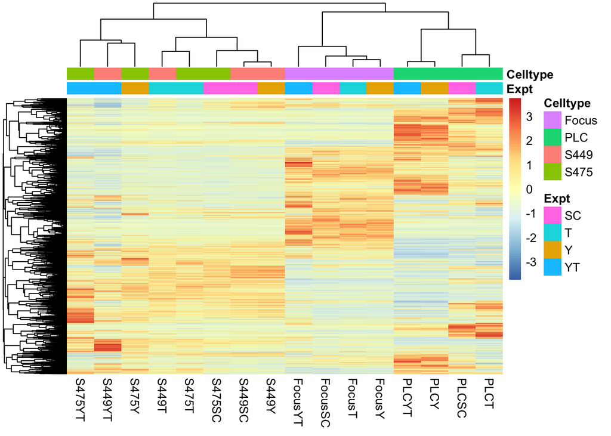

```r
HEATMAP_HEIGHT <- 45 # inchescol
HEATMAP_WIDTH  <- 15
annotation <- data.frame(Expt = Condition, Celltype=Subject2)
rownames(annotation) <- colnames(counts5)
pheatmap(fpkm_matrix,
         , width=HEATMAP_WIDTH, height=HEATMAP_HEIGHT
         , scale="row"  # actually scale each row
         , clustering_distance_rows="correlation" # or: euclidean
         , clustering_distance_cols="correlation"
         , clustering_method="complete"
         , display_numbers=FALSE
         , border_color="#00000000" # note: the last two digits here are the alpha channel/ transparency
         , show_rownames=FALSE, show_colnames = TRUE
         , annotation = annotation
         , fontsize_row=3.5)
```

This heatmap confirms the pattern seen in the dendrogram and PCA plot.

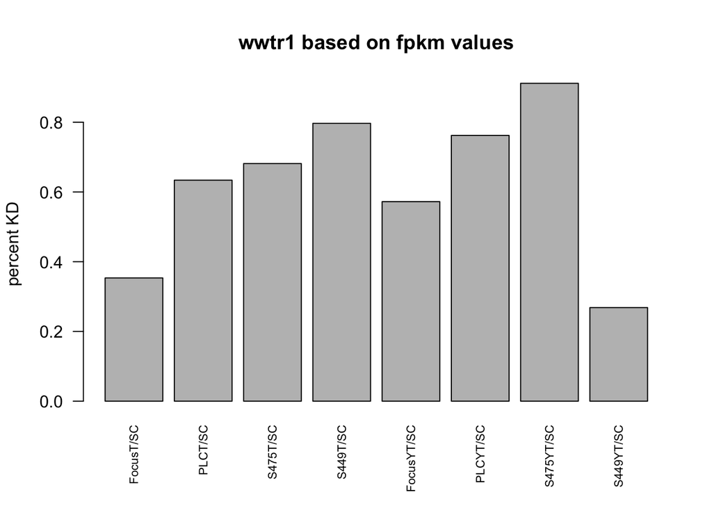

```r
y_combined <- DGEList(counts=counts5)
fpkm_matrix = rpkm (y_combined, gene.length=counts1[keep,"Length"], log = FALSE)
#wwtr1
fpkm_matrix_wwtr1 = fpkm_matrix[which(rownames(fpkm_matrix) == "ENSG00000018408"), ]
fpkm_matrix_wwtr1_percent = c(cbind(fpkm_matrix_wwtr1["FocusT"]/fpkm_matrix_wwtr1[ "FocusSC"], fpkm_matrix_wwtr1["PLCT"]/fpkm_matrix_wwtr1[ "PLCSC"], fpkm_matrix_wwtr1["S475T"]/fpkm_matrix_wwtr1[ "S475SC"], fpkm_matrix_wwtr1["S449T"]/fpkm_matrix_wwtr1[ "S449SC"], fpkm_matrix_wwtr1["FocusYT"]/fpkm_matrix_wwtr1[ "FocusSC"], fpkm_matrix_wwtr1["PLCYT"]/fpkm_matrix_wwtr1[ "PLCSC"], fpkm_matrix_wwtr1["S475YT"]/fpkm_matrix_wwtr1[ "S475SC"], fpkm_matrix_wwtr1["S449YT"]/fpkm_matrix_wwtr1[ "S449SC"] ))
names(fpkm_matrix_wwtr1_percent ) = c("FocusT/SC", "PLCT/SC", "S475T/SC", "S449T/SC", "FocusYT/SC", "PLCYT/SC", "S475YT/SC", "S449YT/SC")

#barplot(fpkm_matrix_wwtr1, las=2)
barplot(fpkm_matrix_wwtr1_percent, las=2, cex.names=.7, ylab= "percent KD", main="wwtr1 based on fpkm values")
```

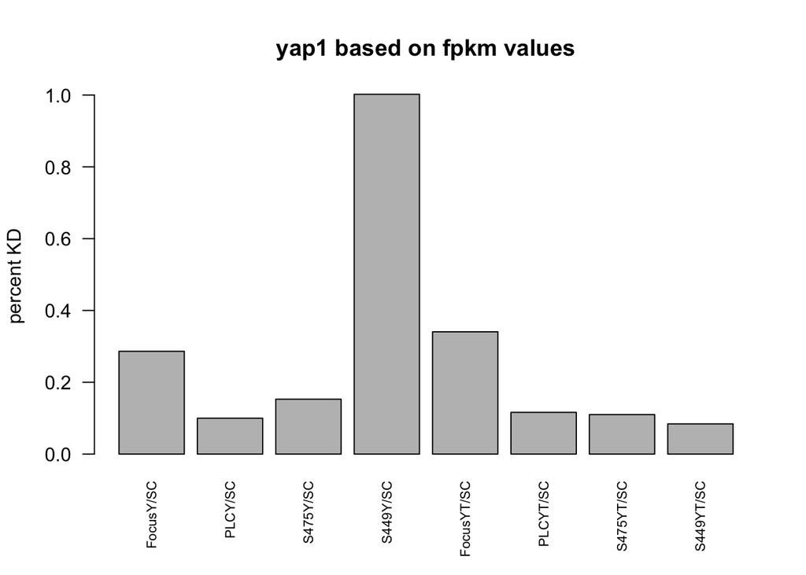

```r
#yap1
fpkm_matrix_yap1 = fpkm_matrix[which(rownames(fpkm_matrix) == "ENSG00000137693"), ]
fpkm_matrix_yap1_percent = c(cbind(fpkm_matrix_yap1["FocusY"]/fpkm_matrix_yap1[ "FocusSC"], fpkm_matrix_yap1["PLCY"]/fpkm_matrix_yap1[ "PLCSC"], fpkm_matrix_yap1["S475Y"]/fpkm_matrix_yap1[ "S475SC"], fpkm_matrix_yap1["S449Y"]/fpkm_matrix_yap1[ "S449SC"], fpkm_matrix_yap1["FocusYT"]/fpkm_matrix_yap1[ "FocusSC"], fpkm_matrix_yap1["PLCYT"]/fpkm_matrix_yap1[ "PLCSC"], fpkm_matrix_yap1["S475YT"]/fpkm_matrix_yap1[ "S475SC"], fpkm_matrix_yap1["S449YT"]/fpkm_matrix_yap1[ "S449SC"] ))
names(fpkm_matrix_yap1_percent ) = c("FocusY/SC", "PLCY/SC", "S475Y/SC", "S449Y/SC", "FocusYT/SC", "PLCYT/SC", "S475YT/SC", "S449YT/SC")
#barplot(fpkm_matrix_yap1, las=2)
barplot(fpkm_matrix_yap1_percent, las=2,  cex.names=.7, ylab= "percent KD", main = "yap1 based on fpkm values")
```

Fit the model and estimate dispersion value.

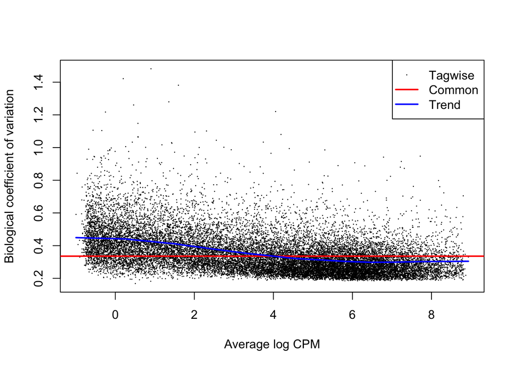

```r
y_for_DE <- DGEList(counts=counts5)
y_for_DE <- calcNormFactors(y_for_DE)
y_for_DE = estimateDisp(y_for_DE, design=design_matrix2)
plotBCV(y_for_DE)
```

```r
fit <- glmFit(y_for_DE, design=design_matrix2, dispersion=y_for_DE$trended.dispersion)
```

```r
lrt_T <- glmLRT(fit,coef = "ConditionT")
topTags(lrt_T)
```

```
## Coefficient:  ConditionT
##                     logFC   logCPM       LR       PValue          FDR
## ENSG00000099974 -2.021209 5.776544 36.92594 1.227027e-09 2.603507e-05
## ENSG00000099977 -1.947754 5.821635 34.76064 3.728359e-09 3.955416e-05
## ENSG00000241313 -2.017111 3.155548 25.53381 4.346986e-07 3.074478e-03
## ENSG00000164171  1.564548 7.921965 24.07899 9.246363e-07 4.904733e-03
## ENSG00000153904 -1.542140 6.925700 23.15304 1.496066e-06 6.348704e-03
## ENSG00000105976  1.485895 8.495696 21.83559 2.970385e-06 9.235672e-03
## ENSG00000173432 -1.824441 4.778843 21.78678 3.046927e-06 9.235672e-03
## ENSG00000159055 -1.614255 4.480648 21.29577 3.936000e-06 1.043926e-02
## ENSG00000120937 -2.123615 3.703030 18.94732 1.343780e-05 3.168035e-02
## ENSG00000138463 -1.484941 4.503708 18.61541 1.599223e-05 3.393232e-02
```

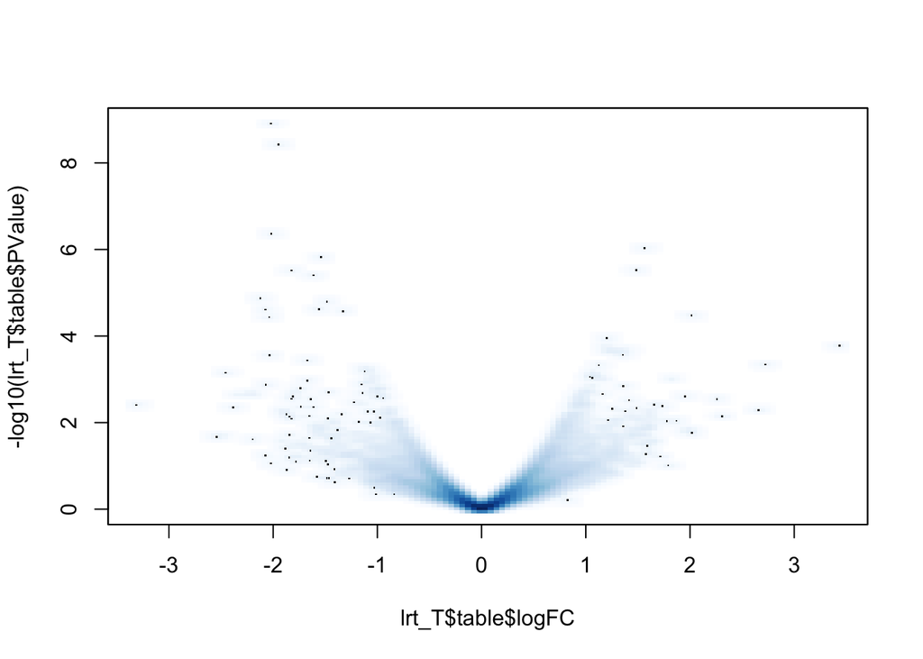

```r
smoothScatter(x=lrt_T$table$logFC, y=-log10(lrt_T$table$PValue))
```

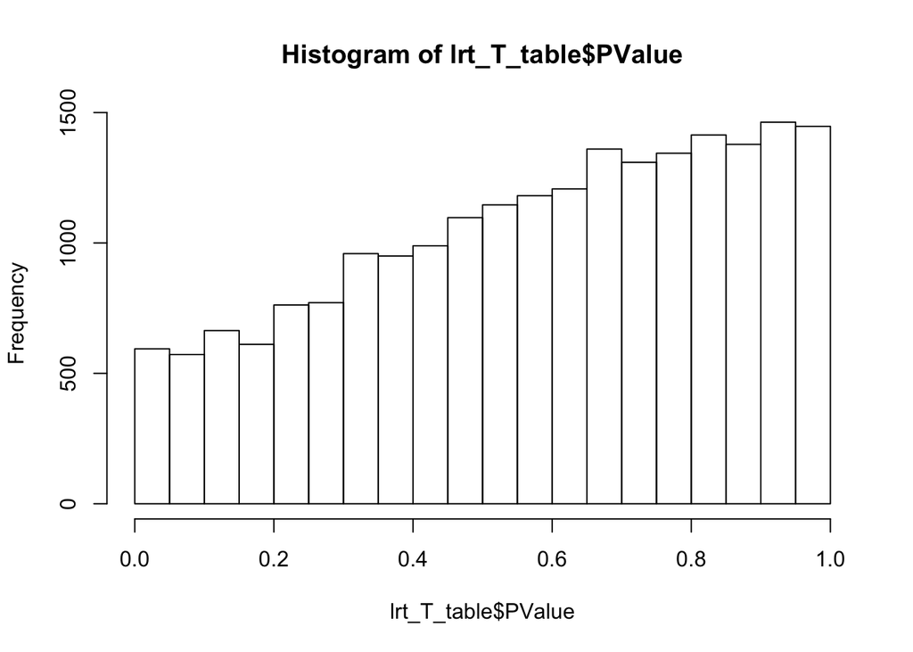

```r
lrt_T_table = data.frame(lrt_T$table, p.adjust(lrt_T$table$PValue, method = "BH"))
colnames(lrt_T_table) = c(colnames(lrt_T$table), "adjPVal_BH")
hist(lrt_T_table$PValue)
```

SC vs Y

```r
lrt_Y <- glmLRT(fit,coef = "ConditionY")
topTags(lrt_Y)
```

```
## Coefficient:  ConditionY
##                     logFC   logCPM       LR       PValue          FDR
## ENSG00000128564  3.111090 5.124186 63.11040 1.954390e-15 4.146825e-11
## ENSG00000267881 -6.925106 4.261791 60.14461 8.813784e-15 6.277676e-11
## ENSG00000275266  5.996092 4.401853 60.13077 8.875967e-15 6.277676e-11
## ENSG00000280390 -6.101469 4.897238 56.16611 6.659975e-14 3.532784e-10
## ENSG00000086548 -5.406648 5.926350 55.61946 8.794857e-14 3.732186e-10
## ENSG00000107159  2.575217 5.302143 49.54432 1.939401e-12 6.858368e-09
## ENSG00000130600  4.171126 6.787090 43.93066 3.402174e-11 1.031248e-07
## ENSG00000284010  5.445078 3.702405 39.88590 2.692400e-10 7.140918e-07
## ENSG00000135346  4.895458 3.969102 39.58812 3.135855e-10 7.392953e-07
## ENSG00000274866  5.024080 4.055661 38.14559 6.565799e-10 1.393131e-06
```

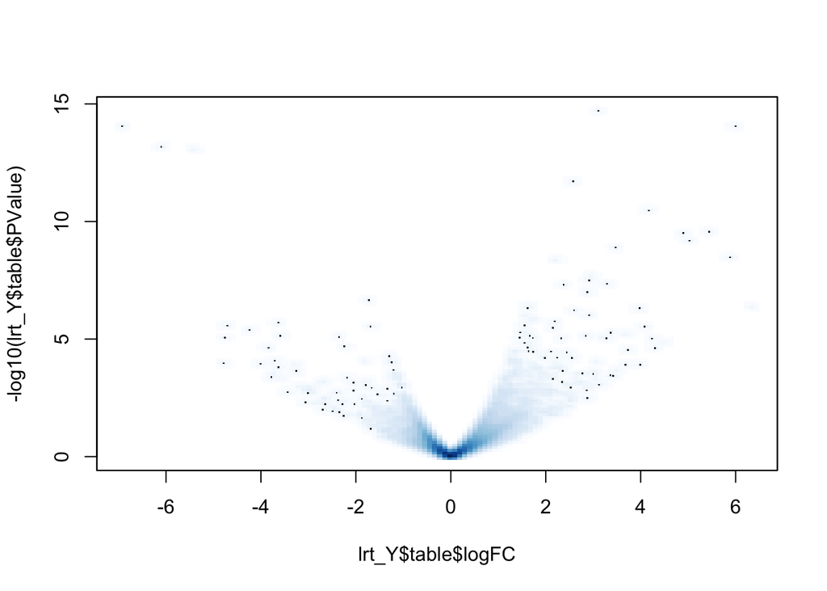

```r
smoothScatter(x=lrt_Y$table$logFC, y=-log10(lrt_Y$table$PValue))
```

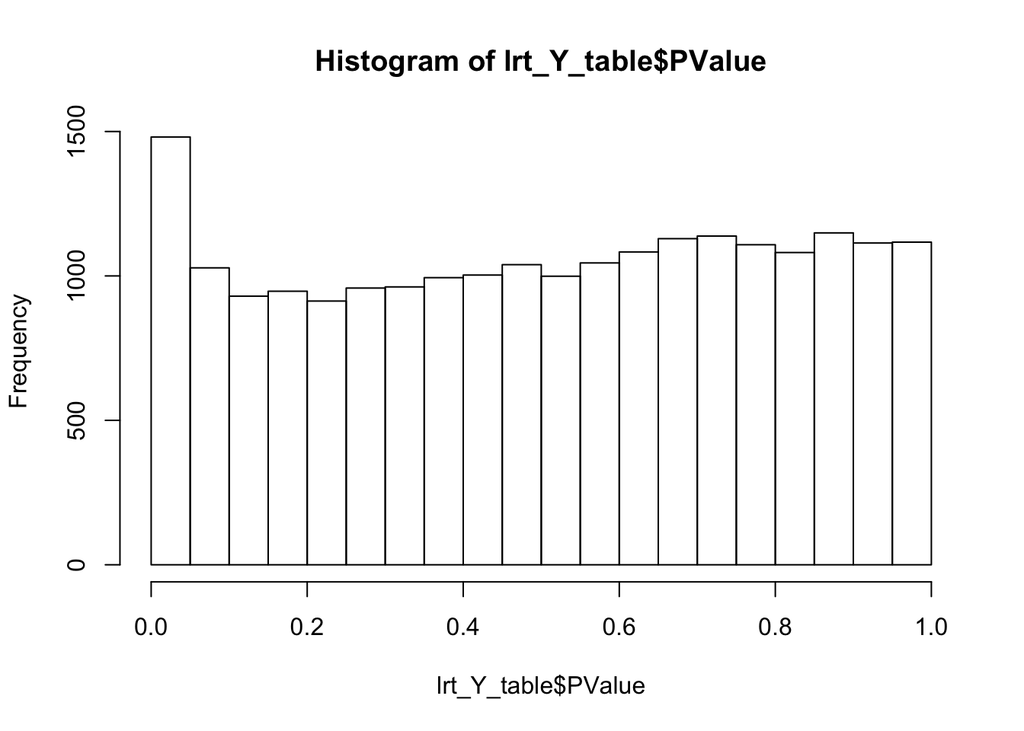

```r
lrt_Y_table = data.frame(lrt_Y$table, p.adjust(lrt_Y$table$PValue, method = "BH"))
colnames(lrt_Y_table) = c(colnames(lrt_Y$table), "adjPVal_BH")
hist(lrt_Y_table$PValue)
```

SC vs YT

```r
lrt_YT <- glmLRT(fit,coef = "ConditionYT")
topTags(lrt_YT)
```

```
## Coefficient:  ConditionYT
##                    logFC   logCPM        LR       PValue          FDR
## ENSG00000181444 4.254222 5.266445 102.16111 5.118504e-24 1.086044e-19
## ENSG00000204044 3.677992 7.524964  97.26333 6.069397e-23 6.439023e-19
## ENSG00000171951 4.632456 3.424569  89.25656 3.467905e-21 2.452733e-17
## ENSG00000259207 3.812053 6.860603  85.49128 2.327259e-20 1.115711e-16
## ENSG00000113369 3.239965 6.502345  85.17509 2.730811e-20 1.115711e-16
## ENSG00000128564 3.605549 5.124186  84.88959 3.154995e-20 1.115711e-16
## ENSG00000137959 6.426154 2.307243  82.11934 1.281128e-19 3.883281e-16
## ENSG00000148344 3.805925 7.716616  81.02243 2.231706e-19 5.919042e-16
## ENSG00000259753 3.635031 6.225942  76.85862 1.836451e-18 4.329536e-15
## ENSG00000157601 3.736414 5.636069  74.42870 6.286836e-18 1.333941e-14
```

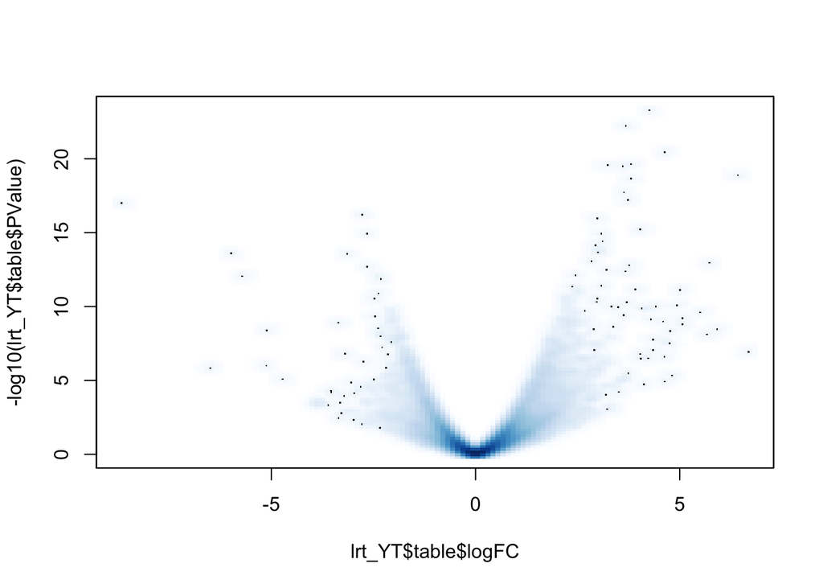

```r
smoothScatter(x=lrt_YT$table$logFC, y=-log10(lrt_YT$table$PValue))
```

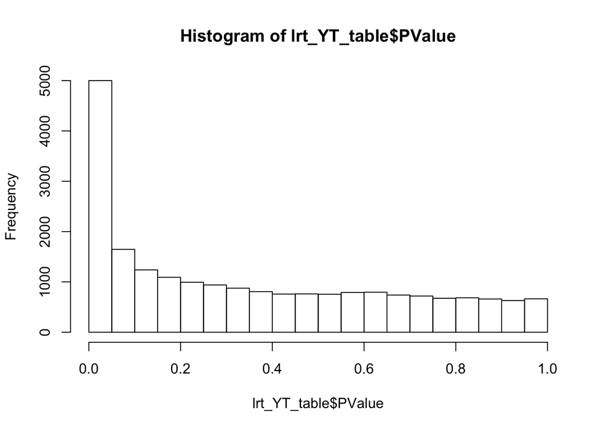

```r
lrt_YT_table = data.frame(lrt_YT$table, p.adjust(lrt_YT$table$PValue, method = "BH"))
colnames(lrt_YT_table) = c(colnames(lrt_YT$table), "adjPVal_BH")
hist(lrt_YT_table$PValue)
```

Format output into excel sheet.

```r
genes = rownames(counts5)
ensembl = useEnsembl(biomart="ensembl", dataset="hsapiens_gene_ensembl")
head(listAttributes(ensembl), 30)
```

```
##                               name
## 1                  ensembl_gene_id
## 2          ensembl_gene_id_version
## 3            ensembl_transcript_id
## 4    ensembl_transcript_id_version
## 5               ensembl_peptide_id
## 6       ensembl_peptide_id_version
## 7                  ensembl_exon_id
## 8                      description
## 9                  chromosome_name
## 10                  start_position
## 11                    end_position
## 12                          strand
## 13                            band
## 14                transcript_start
```

[output cut: 47 more lines]

```r
hgnc_swissprot <- getBM(attributes=c('ensembl_gene_id','hgnc_symbol','description'),filters = 'ensembl_gene_id',  values = genes , mart = ensembl)

fpkm_log_matrix2 = rpkm (y_for_DE, gene.length=counts1[keep,"Length"], log = TRUE)
index = match (genes, hgnc_swissprot$ensembl_gene_id)
results = data.frame(hgnc_swissprot[index,], counts5, fpkm_log_matrix2, lrt_T_table, lrt_Y_table, lrt_YT_table)
colnames(results) = c(
                    colnames(hgnc_swissprot[index,])
                  , unlist(lapply (colnames(counts5), function(x) paste(x, "counts", sep="_")))
                  , unlist(lapply (colnames(fpkm_log_matrix2), function(x) paste(x, "fpkm", sep="_")))
                  , unlist(lapply (colnames(lrt_T_table), function(x) paste(x, "_SC_vs_T", sep="_")))
                  , unlist(lapply (colnames(lrt_Y_table), function(x) paste(x, "_SC_vs_Y", sep="_")))
                  , unlist(lapply (colnames(lrt_YT_table), function(x) paste(x, "_SC_vs_YT", sep="_"))) )
curr_date = format(Sys.time(), "%a_%b_%d_%H_hrs_%M_min_%S_sec_%Y")
write.table(results, paste0("~/Downloads/Chen_", curr_date, ".xls"), row.names=F, col.names=T, sep="\t")
```

Heatmap of DE genes.

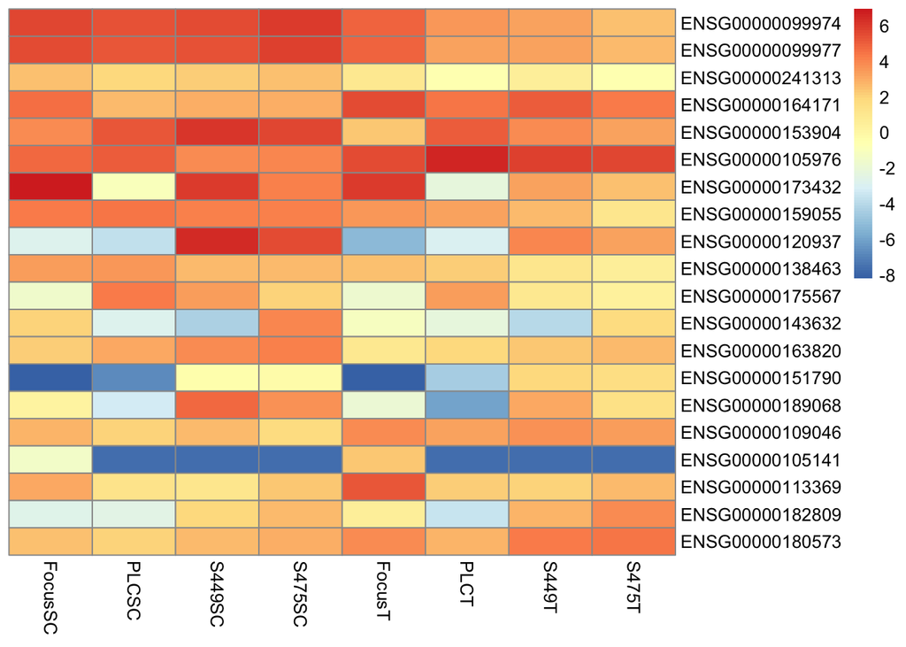

```r
pheatmap(fpkm_log_matrix2[order(lrt_T_table$PValue, decreasing = F)[1:20],c(colnames(fpkm_log_matrix2)[grep("SC", colnames(fpkm_log_matrix2))],"FocusT", "PLCT", "S449T", "S475T")], cluster_rows=FALSE, cluster_cols=FALSE)
```

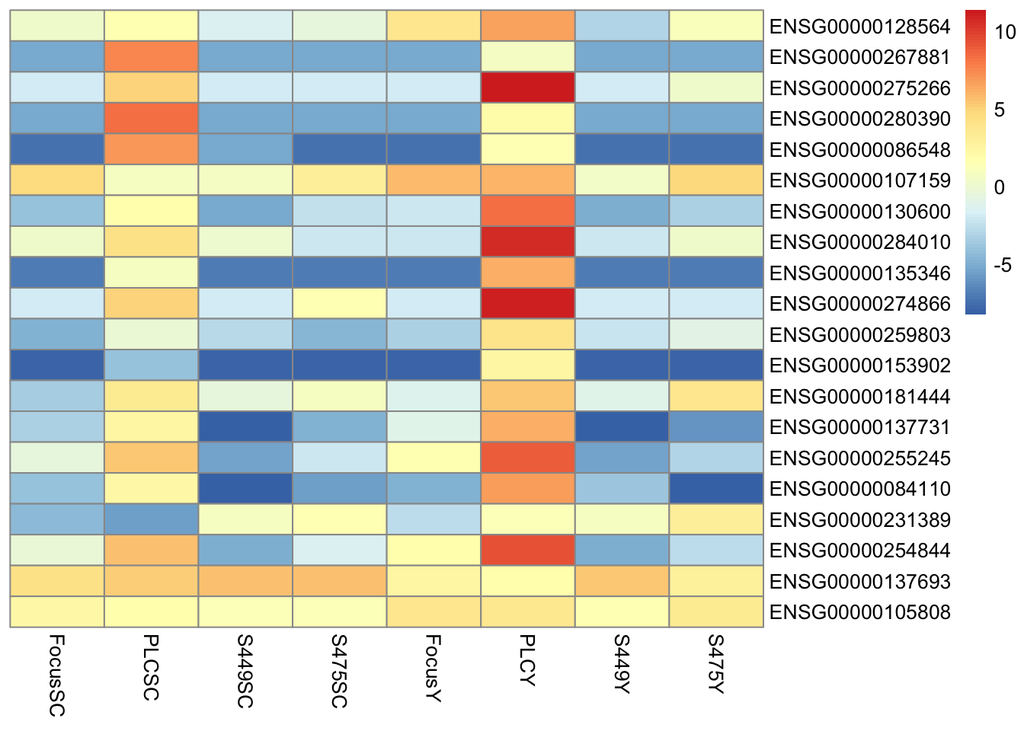

```r
pheatmap(fpkm_log_matrix2[order(lrt_Y_table$PValue, decreasing = F)[1:20],c(colnames(fpkm_log_matrix2)[grep("SC", colnames(fpkm_log_matrix2))],"FocusY", "PLCY", "S449Y", "S475Y")], cluster_rows=FALSE, cluster_cols=FALSE)
```

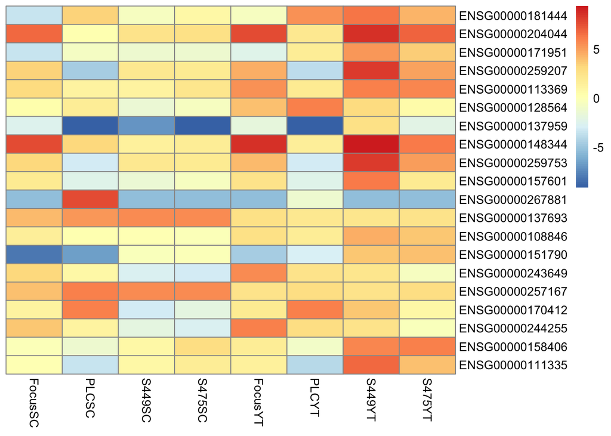

```r
pheatmap(fpkm_log_matrix2[order(lrt_YT_table$PValue, decreasing = F)[1:20],c(colnames(fpkm_log_matrix2)[grep("SC", colnames(fpkm_log_matrix2))],colnames(fpkm_log_matrix2)[grep("YT", colnames(fpkm_log_matrix2))] )], cluster_rows=FALSE, cluster_cols=FALSE)
```

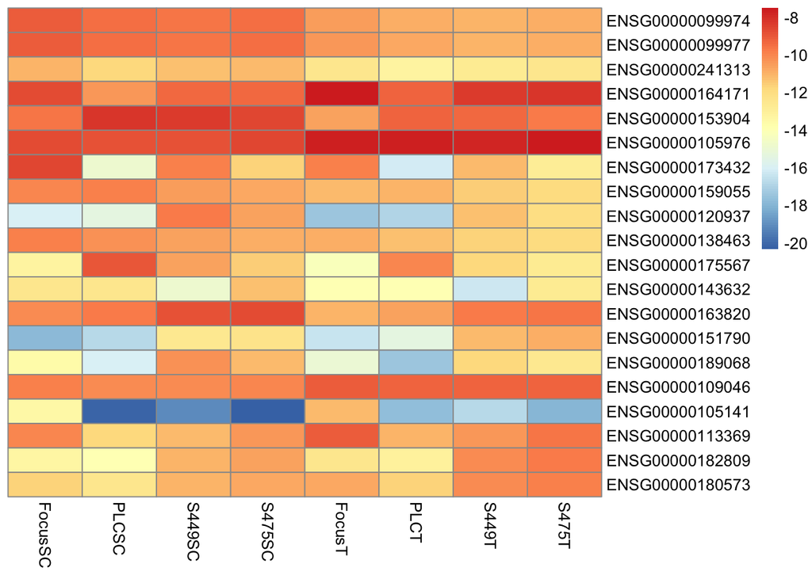

```r
#try this
mean_values = (fit$coefficients %*% t(design_matrix2))
colnames(mean_values) = colnames(counts5)
rownames(mean_values) = rownames(counts5)

pheatmap(mean_values[order(lrt_T_table$PValue, decreasing = F)[1:20],c(colnames(fpkm_log_matrix2)[grep("SC", colnames(fpkm_log_matrix2))],"FocusT", "PLCT", "S449T", "S475T")], cluster_rows=FALSE, cluster_cols=FALSE)
```

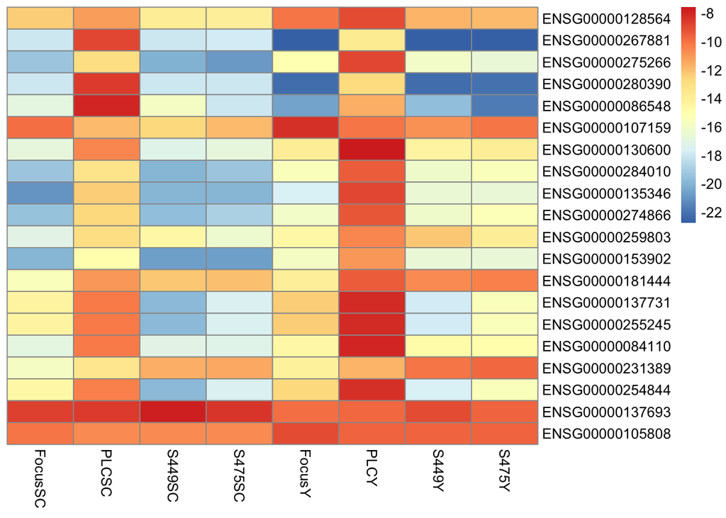

```r
pheatmap(mean_values[order(lrt_Y_table$PValue, decreasing = F)[1:20],c(colnames(fpkm_log_matrix2)[grep("SC", colnames(fpkm_log_matrix2))],"FocusY", "PLCY", "S449Y", "S475Y")], cluster_rows=FALSE, cluster_cols=FALSE)
```

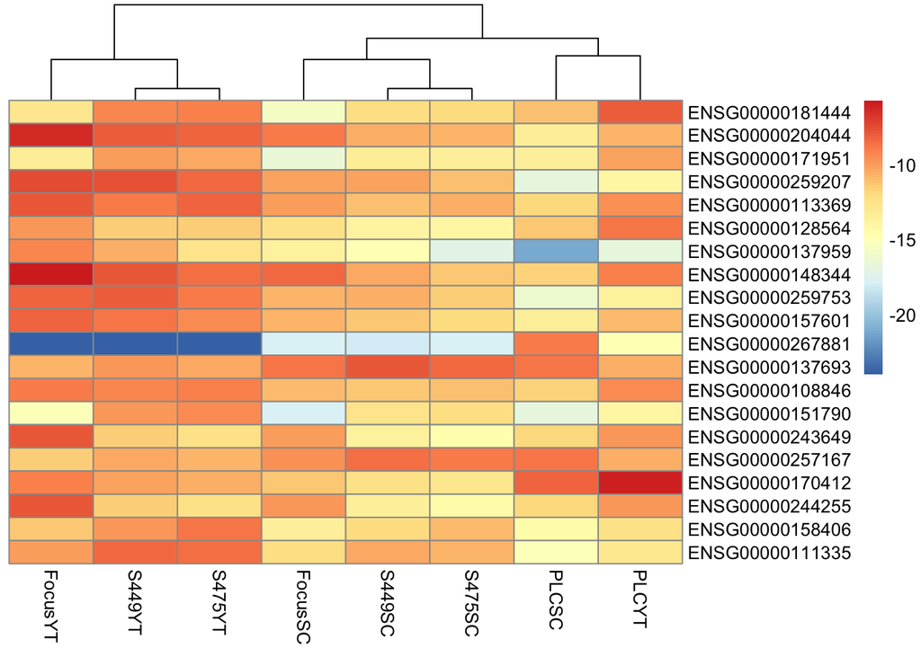

```r
pheatmap(mean_values[order(lrt_YT_table$PValue, decreasing = F)[1:20],c(colnames(fpkm_log_matrix2)[grep("SC", colnames(fpkm_log_matrix2))],colnames(fpkm_log_matrix2)[grep("YT", colnames(fpkm_log_matrix2))] )], cluster_rows=FALSE, cluster_cols=TRUE)
```

```r
#edit column description
write.table(colnames(results), "~/Downloads/column_description.txt", quote=F, col.names=F, row.names=F,sep="\t")
```